# 2019OctoberHawaii_report

Tim C.

01/07/2020

### Personnel

| collectors |
| --- |
| lorainastinson2024@u.northwestern.edu |
| claire.buchanan@northwestern.edu |
| NA |

| isolators |
| --- |
| gaotian52@gmail.com |
| nicoleroberto2018@u.northwestern.edu |
| claire.buchanan@northwestern.edu |
| robyn.tanny@northwestern.edu |
| lorainastinson2024@u.northwestern.edu |
| NA |

### Review locations

[interactive chart not shown]

Use this map to manually check latitidue and longitude of collection records.  
*Red points* are located using `fulcrum` lat,long and may need to be corrected.  
*Green points* are located using `photo` lat,long and are usually accurate.  
**Location review results:** No manual corrections for collection locations.

### collection report

| collection report | value |
| --- | --- |
| total number of distinct collections | 509 |
| total number of distinct collections NAs removed | 508 |
| collections with nematodes | 236 |
| collections with tracks only | 125 |
| collections without nematodes | 124 |
| collection percentage with nematodes | 46.5% |
| collection percentage with tracks only | 24.6% |
| collection percentage with no worms | 24.4% |
| collections with duplicated ids | 0 |
| collections with NA for colleciton id | 8 |
| collections without paired isolation data | 23 |
| collections with location method ‘photo’ | 467 |
| collections with location method ‘fulcrum’ | 41 |
| collection percentage with loc method ‘photo’ | 91.9% |
| collection percentage with loc method ‘fulcrum’ | 8.1% |
| collections with altitude method ‘geonames’ | 490 |
| collections with altitude method ‘fulcrum’ | 18 |
| collection percentage with altitude method ‘geonames’ | 96.5% |
| collection percentage with altitude method ‘fulcrum’ | 3.5% |

### isolation report

| isolation report | value |
| --- | --- |
| total number of distinct isolations | 690 |
| total number of distinct isolations NAs removed | 689 |
| average isolations per collection with worms | 2.89787234042553 |
| isolations with duplicated ids |  |
| isolations without paired collection data | (8 plates) S-0141,S-0143,S-0144,S-0190,S-0229,S-0230,S-0231,S-0305 |
| Not genotyped | 364 |
| PCR - | 276 |
| O. myriophilus | 2 |
| Osceius | 1 |
| C. tropicalis | 10 |
| Neoholmesia japona | 1 |
| C. elegans | 6 |
| C. briggsae | 14 |
| Oscheius myriophilus | 1 |
| Other PCR + | 1 |
| Caenorhabditis kamaaina | 4 |
| R. terricola | 1 |
| n/a | 2 |

**NOTE:** 2 *C. elegans* isolations do not have paired collection data. If we include these isolations there are 8 *C. elegans* isolated not 6.

### duplications report

0 c_label(s) duplicated in nematode_field_sampling.csv

| fulcrum_id | created_at | updated_at | created_by | updated_by | system_created_at | system_updated_at | version | status | project | assigned_to | latitude | longitude | geometry | sample_photo | sample_photo_caption | sample_photo_url | substrate | substrate_other | substrate_notes | landscape | sky_view | gridsect | gridsect_index | grid_sect_direction | gridsect_radius | substrate_temperature | substrate_moisture | ambient_humidity | ambient_temperature_c | … |
| --- | --- | --- | --- | --- | --- | --- | --- | --- | --- | --- | --- | --- | --- | --- | --- | --- | --- | --- | --- | --- | --- | --- | --- | --- | --- | --- | --- | --- | --- | --- |

0 isolation id(s) duplicated in nematode_isolation.csv

| fulcrum_id | created_at | updated_at | created_by | updated_by | system_created_at | system_updated_at | version | status | project | assigned_to | latitude | longitude | geometry | c_label | worms_on_sample | approximate_number_of_worms | photos | photos_caption | photos_url | date | time | gps_altitude | gps_horizontal_accuracy | gps_vertical_accuracy | gps_speed | gps_course | distinct_fulcrum_id_count | distinct_c_label_count |
| --- | --- | --- | --- | --- | --- | --- | --- | --- | --- | --- | --- | --- | --- | --- | --- | --- | --- | --- | --- | --- | --- | --- | --- | --- | --- | --- | --- | --- |

9 collection(s) with duplicated isolations in nematode_isolation.csv

| fulcrum_id | created_at | updated_at | created_by | updated_by | system_created_at | system_updated_at | version | status | project | assigned_to | latitude | longitude | geometry | c_label | worms_on_sample | approximate_number_of_worms | photos | photos_caption | photos_url | date | time | gps_altitude | gps_horizontal_accuracy | gps_vertical_accuracy | gps_speed | gps_course | distinct_fulcrum_id_count | distinct_c_label_count |
| --- | --- | --- | --- | --- | --- | --- | --- | --- | --- | --- | --- | --- | --- | --- | --- | --- | --- | --- | --- | --- | --- | --- | --- | --- | --- | --- | --- | --- |
| ba087951-d290-414e-9a4f-2343bd38e096 | 2019-10-31 19:38:25 UTC | 2019-10-31 19:38:44 UTC | robyn.tanny@northwestern.edu | robyn.tanny@northwestern.edu | 2019-10-31 19:50:50 UTC | 2019-10-31 19:50:50 UTC | 1 | NA | 2019OctoberHawaii | NA | 42.05653 | -87.67376 | POINT (-87.6737561 42.0565289) | 3c1b93b7-673b-4f7e-80df-1636add305e0 | Tracks | NA | NA | NA | NA | 2019-10-31 | 14:38:00 | 162.6 | 14.668 | NA | NA | 215.55115 | 1 | 2 |
| 6f5a978c-7ec8-4d3d-af6a-39e7d09f16c7 | 2019-10-31 19:40:13 UTC | 2019-10-31 19:40:37 UTC | robyn.tanny@northwestern.edu | robyn.tanny@northwestern.edu | 2019-10-31 19:50:50 UTC | 2019-10-31 19:50:50 UTC | 1 | NA | 2019OctoberHawaii | NA | 42.05652 | -87.67377 | POINT (-87.673767 42.0565211) | 59b57858-c42b-402c-abf8-5a870373ca4a | Tracks | NA | NA | NA | NA | 2019-10-31 | 14:40:00 | 162.6 | 13.125 | NA | NA | 231.77632 | 1 | 2 |
| 5b9ee3c8-c131-4154-b8be-f968df1cd7fe | 2019-10-31 19:43:05 UTC | 2019-10-31 19:44:21 UTC | robyn.tanny@northwestern.edu | robyn.tanny@northwestern.edu | 2019-10-31 19:50:50 UTC | 2019-10-31 19:50:50 UTC | 1 | NA | 2019OctoberHawaii | NA | 42.05653 | -87.67376 | POINT (-87.6737561 42.0565278) | 5e70b43d-0e80-40a6-9cf5-eb48df03cc04 | Yes | Very Few (1-3) | NA | NA | NA | 2019-10-31 | 14:43:00 | 162.6 | 14.678 | NA | NA | NA | 1 | 2 |
| 23402ce9-155c-41df-adb9-89a03d1303fb | 2019-10-31 19:48:50 UTC | 2019-10-31 19:49:02 UTC | robyn.tanny@northwestern.edu | robyn.tanny@northwestern.edu | 2019-10-31 19:50:51 UTC | 2019-10-31 19:50:51 UTC | 1 | NA | 2019OctoberHawaii | NA | 42.05653 | -87.67376 | POINT (-87.6737564 42.056529) | 567ba31c-f799-4e48-b6e9-3ed3f77f88dc | Tracks | NA | NA | NA | NA | 2019-10-31 | 14:48:00 | 162.6 | 13.183 | NA | NA | 320.95105 | 1 | 2 |
| 08937299-bb3a-4ac9-b101-513d58ba5968 | 2019-10-31 19:50:29 UTC | 2019-10-31 19:50:43 UTC | robyn.tanny@northwestern.edu | robyn.tanny@northwestern.edu | 2019-10-31 19:50:52 UTC | 2019-10-31 19:50:52 UTC | 1 | NA | 2019OctoberHawaii | NA | 42.05652 | -87.67376 | POINT (-87.6737609 42.0565182) | f11ec211-5e2d-45bf-82df-47e008dbe080 | Tracks | NA | NA | NA | NA | 2019-10-31 | 14:50:00 | 162.6 | 13.475 | NA | NA | 200.87924 | 1 | 2 |
| 27f5a645-eb43-405a-9c79-1bccb4abe839 | 2019-10-31 19:23:50 UTC | 2019-10-31 19:26:57 UTC | lorainastinson2024@u.northwestern.edu | lorainastinson2024@u.northwestern.edu | 2019-10-31 21:33:02 UTC | 2019-10-31 21:33:02 UTC | 1 | NA | 2019OctoberHawaii | NA | 42.05652 | -87.67377 | POINT (-87.6737677 42.0565214) | 67d47dc2-1c52-455c-ad46-b340bc57a920 | No | NA | 1d15af27-5803-4118-8218-46662835553b | NA | https://web.fulcrumapp.com/photos/view?photos=1d15af27-5803-4118-8218-46662835553b | 2019-10-31 | 14:23:00 | 162.6 | 13.174 | NA | NA | 345.02118 | 1 | 2 |
| cee218c8-aad0-4e1b-9a04-0b084439cfab | 2019-10-31 20:00:20 UTC | 2019-10-31 20:02:53 UTC | lorainastinson2024@u.northwestern.edu | lorainastinson2024@u.northwestern.edu | 2019-10-31 21:33:03 UTC | 2019-10-31 21:33:03 UTC | 1 | NA | 2019OctoberHawaii | NA | 42.05652 | -87.67376 | POINT (-87.6737631 42.0565196) | 304f25ee-aae8-4f5c-bded-c9d9287380ef | Tracks | NA | 6c3b70c6-eb90-44aa-8380-b87099537ab7 | NA | https://web.fulcrumapp.com/photos/view?photos=6c3b70c6-eb90-44aa-8380-b87099537ab7 | 2019-10-31 | 15:00:00 | 162.5 | 14.273 | NA | NA | NA | 1 | 2 |
| d4c2a996-91fe-4d64-9561-d3cb7a3b8a58 | 2019-10-31 20:03:53 UTC | 2019-10-31 20:07:19 UTC | lorainastinson2024@u.northwestern.edu | lorainastinson2024@u.northwestern.edu | 2019-10-31 21:33:04 UTC | 2019-10-31 21:33:04 UTC | 1 | NA | 2019OctoberHawaii | NA | 42.05652 | -87.67378 | POINT (-87.6737776 42.056517) | 6d65aef0-bf2e-484a-a5d6-23dda632ea81 | Tracks | NA | b4ad2445-5b5c-4fe1-ba11-1f620309597e | NA | https://web.fulcrumapp.com/photos/view?photos=b4ad2445-5b5c-4fe1-ba11-1f620309597e | 2019-10-31 | 15:03:00 | 162.6 | 13.315 | NA | NA | 262.22700 | 1 | 2 |
| 5535470e-d82d-4ca4-ac77-860ea62c51c1 | 2019-10-31 20:14:46 UTC | 2019-10-31 20:16:29 UTC | lorainastinson2024@u.northwestern.edu | lorainastinson2024@u.northwestern.edu | 2019-10-31 21:33:04 UTC | 2019-10-31 21:33:04 UTC | 1 | NA | 2019OctoberHawaii | NA | 42.05653 | -87.67376 | POINT (-87.6737557 42.056529) | 890dbc36-f303-430a-aa5a-f2bd1d705333 | Tracks | NA | d719ffde-755e-43b4-9e25-255a000c6c1e | NA | https://web.fulcrumapp.com/photos/view?photos=d719ffde-755e-43b4-9e25-255a000c6c1e | 2019-10-31 | 15:14:00 | 162.6 | 14.378 | NA | NA | NA | 1 | 2 |
| 8ad23d90-c0b8-4aa1-b135-f2d1fead94d4 | 2019-11-01 16:59:16 UTC | 2019-11-01 16:59:49 UTC | claire.buchanan@northwestern.edu | claire.buchanan@northwestern.edu | 2019-11-01 17:03:29 UTC | 2019-11-01 17:03:29 UTC | 1 | NA | 2019OctoberHawaii | NA | 42.05654 | -87.67373 | POINT (-87.6737337 42.0565418) | f11ec211-5e2d-45bf-82df-47e008dbe080 | No | NA | 76ca8333-9e96-4cf1-95c2-a348c9b711dd | NA | https://web.fulcrumapp.com/photos/view?photos=76ca8333-9e96-4cf1-95c2-a348c9b711dd | 2019-11-01 | 11:59:00 | 162.6 | 16.160 | NA | NA | 349.02667 | 1 | 2 |
| 036a80ac-3372-4c3c-b40d-edfa0a9d68cc | 2019-11-01 16:59:51 UTC | 2019-11-01 17:00:21 UTC | claire.buchanan@northwestern.edu | claire.buchanan@northwestern.edu | 2019-11-01 17:03:29 UTC | 2019-11-01 17:03:29 UTC | 1 | NA | 2019OctoberHawaii | NA | 42.05653 | -87.67374 | POINT (-87.673742 42.0565268) | 567ba31c-f799-4e48-b6e9-3ed3f77f88dc | Tracks | NA | 300535c4-e8fd-4182-8221-6d23029948f9 | NA | https://web.fulcrumapp.com/photos/view?photos=300535c4-e8fd-4182-8221-6d23029948f9 | 2019-11-01 | 11:59:00 | 162.6 | 13.356 | NA | NA | 254.23123 | 1 | 2 |
| 6fa1a690-ea42-49a7-b86d-e7181b9f68bf | 2019-11-01 17:00:23 UTC | 2019-11-01 17:01:06 UTC | claire.buchanan@northwestern.edu | claire.buchanan@northwestern.edu | 2019-11-01 17:03:30 UTC | 2019-11-01 17:03:30 UTC | 1 | NA | 2019OctoberHawaii | NA | 42.05653 | -87.67373 | POINT (-87.6737301 42.0565263) | 5e70b43d-0e80-40a6-9cf5-eb48df03cc04 | Tracks | NA | 14476275-e34e-4b4d-a261-eb50d59ab6b8 | NA | https://web.fulcrumapp.com/photos/view?photos=14476275-e34e-4b4d-a261-eb50d59ab6b8 | 2019-11-01 | 12:00:00 | 162.6 | 14.712 | NA | NA | 94.99683 | 1 | 2 |
| 6dbecd43-e4e3-405f-b4dc-e757ad4449a5 | 2019-11-01 17:01:10 UTC | 2019-11-01 17:02:20 UTC | claire.buchanan@northwestern.edu | claire.buchanan@northwestern.edu | 2019-11-01 17:03:30 UTC | 2019-11-01 17:03:30 UTC | 1 | NA | 2019OctoberHawaii | NA | 42.05653 | -87.67373 | POINT (-87.6737303 42.0565283) | 59b57858-c42b-402c-abf8-5a870373ca4a | Tracks | NA | ee669ab8-b39c-4fab-8a38-22362b932026 | NA | https://web.fulcrumapp.com/photos/view?photos=ee669ab8-b39c-4fab-8a38-22362b932026 | 2019-11-01 | 12:01:00 | 162.6 | 14.996 | NA | NA | 123.84636 | 1 | 2 |
| 340dbd85-7b9a-4ecb-be5f-ac1ef944e057 | 2019-11-01 17:02:22 UTC | 2019-11-01 17:03:13 UTC | claire.buchanan@northwestern.edu | claire.buchanan@northwestern.edu | 2019-11-01 17:03:31 UTC | 2019-11-01 17:03:31 UTC | 1 | NA | 2019OctoberHawaii | NA | 42.05653 | -87.67374 | POINT (-87.6737418 42.056528) | 3c1b93b7-673b-4f7e-80df-1636add305e0 | Tracks | NA | 76f70a9e-6014-4362-8cf5-ff4bd8a70c17 | NA | https://web.fulcrumapp.com/photos/view?photos=76f70a9e-6014-4362-8cf5-ff4bd8a70c17 | 2019-11-01 | 12:02:00 | 162.6 | 15.442 | NA | NA | 275.76800 | 1 | 2 |
| 55defa80-981e-48aa-8477-73cef5c3ba31 | 2019-11-01 17:03:43 UTC | 2019-11-01 17:06:25 UTC | claire.buchanan@northwestern.edu | claire.buchanan@northwestern.edu | 2019-11-01 17:08:16 UTC | 2019-11-01 17:08:16 UTC | 1 | NA | 2019OctoberHawaii | NA | 42.05653 | -87.67375 | POINT (-87.6737499 42.0565271) | 890dbc36-f303-430a-aa5a-f2bd1d705333 | Yes | Very Few (1-3) | 96f0b31f-e061-47b3-8a43-2518bf452a06 | NA | https://web.fulcrumapp.com/photos/view?photos=96f0b31f-e061-47b3-8a43-2518bf452a06 | 2019-11-01 | 12:03:00 | 162.6 | 13.135 | NA | NA | 226.02576 | 1 | 2 |
| 88a12c25-a129-45e0-9306-c3a232b33552 | 2019-11-01 17:06:29 UTC | 2019-11-01 17:08:08 UTC | claire.buchanan@northwestern.edu | claire.buchanan@northwestern.edu | 2019-11-01 17:08:16 UTC | 2019-11-01 17:08:16 UTC | 1 | NA | 2019OctoberHawaii | NA | 42.05654 | -87.67373 | POINT (-87.673731 42.0565435) | 6d65aef0-bf2e-484a-a5d6-23dda632ea81 | Tracks | NA | 5ac60ee9-8974-4fec-870e-e6ba8bd46c6c | NA | https://web.fulcrumapp.com/photos/view?photos=5ac60ee9-8974-4fec-870e-e6ba8bd46c6c | 2019-11-01 | 12:06:00 | 162.6 | 15.633 | NA | NA | 12.90069 | 1 | 2 |
| 90f59eb1-abf8-4e7a-8ebc-d3148527b831 | 2019-11-01 17:08:22 UTC | 2019-11-01 17:08:48 UTC | claire.buchanan@northwestern.edu | claire.buchanan@northwestern.edu | 2019-11-01 17:10:53 UTC | 2019-11-01 17:10:53 UTC | 1 | NA | 2019OctoberHawaii | NA | 42.05655 | -87.67372 | POINT (-87.673721 42.0565482) | 67d47dc2-1c52-455c-ad46-b340bc57a920 | No | NA | e8bec09c-5f21-4ad0-91dc-d374902f188c | NA | https://web.fulcrumapp.com/photos/view?photos=e8bec09c-5f21-4ad0-91dc-d374902f188c | 2019-11-01 | 12:08:00 | 162.6 | 14.819 | NA | NA | 14.69601 | 1 | 2 |
| e64ca21a-fece-431a-9829-2b81daeda8c7 | 2019-11-01 17:08:54 UTC | 2019-11-01 17:10:45 UTC | claire.buchanan@northwestern.edu | claire.buchanan@northwestern.edu | 2019-11-01 17:10:53 UTC | 2019-11-01 17:10:53 UTC | 1 | NA | 2019OctoberHawaii | NA | 42.05655 | -87.67372 | POINT (-87.6737234 42.0565465) | 304f25ee-aae8-4f5c-bded-c9d9287380ef | Yes | Very Few (1-3) | e4ae923a-61ba-4397-bb22-3fa000ec385d | NA | https://web.fulcrumapp.com/photos/view?photos=e4ae923a-61ba-4397-bb22-3fa000ec385d | 2019-11-01 | 12:08:00 | 162.6 | 16.325 | NA | NA | NA | 1 | 2 |

1 s_label(s) duplicated in nematode_isolation_s_labeled_plates.csv

| fulcrum_id | fulcrum_parent_id | fulcrum_record_id | version | latitude | longitude | geometry | created_at | updated_at | created_by | updated_by | s_label | n |
| --- | --- | --- | --- | --- | --- | --- | --- | --- | --- | --- | --- | --- |
| 8a7e744c-0879-459c-b93f-89a6a59f2f5d | b2d1abee-42bc-4ec5-984c-3f11ef2b948d | b2d1abee-42bc-4ec5-984c-3f11ef2b948d | 1 | 42.05652 | -87.67378 | POINT (-87.6737829 42.0565197) | 2019-10-30 15:32:34 UTC | 2019-10-30 15:33:06 UTC | nicoleroberto2018@u.northwestern.edu | nicoleroberto2018@u.northwestern.edu | S-0298 | 2 |
| 99e00603-2132-4944-ac69-e28a223fb0d5 | b2d1abee-42bc-4ec5-984c-3f11ef2b948d | b2d1abee-42bc-4ec5-984c-3f11ef2b948d | 1 | 42.05653 | -87.67376 | POINT (-87.6737556 42.0565327) | 2019-10-30 15:33:07 UTC | 2019-10-30 15:33:20 UTC | nicoleroberto2018@u.northwestern.edu | nicoleroberto2018@u.northwestern.edu | S-0298 | 2 |

0 s_label(s) duplicated in genotyping sheet

| Shipment # | Box # | s_label | Strip Tube # | Position | lysis_date | pcr_date | Gel Row 1 | Gel Row 2 | Gel Row 3 | MCLab Sequencing Positions | ITS2_pcr_product | species_id_ITS2 | rhabditid_pcr_product | species_id_rhabditid | method_of_determination | notes | n |
| --- | --- | --- | --- | --- | --- | --- | --- | --- | --- | --- | --- | --- | --- | --- | --- | --- | --- |

These dataframes are filtered to show the duplications in the raw data from fulcrum or the genotyping sheet. If the dataframe are empty there is no duplication.  
**Duplication issue 1:** 9 collections were two separate isolation records exist for the same c_label.  
**Solution:** Retained the isolation record based on worm presence. Yes > tracks > no.  
If both isolation records indicate “tracks only” or “no” then we retain the earliest record.  
In no cases did both isolation records indicate worms were present on c_label.  
**Duplication issue 2:** 1 s_label duplicated in the `nematode_isolation_s_labeled_plates.csv`.  
**Solution:** This duplication is removed in `step 5` of process fulcrum script.

### project overview

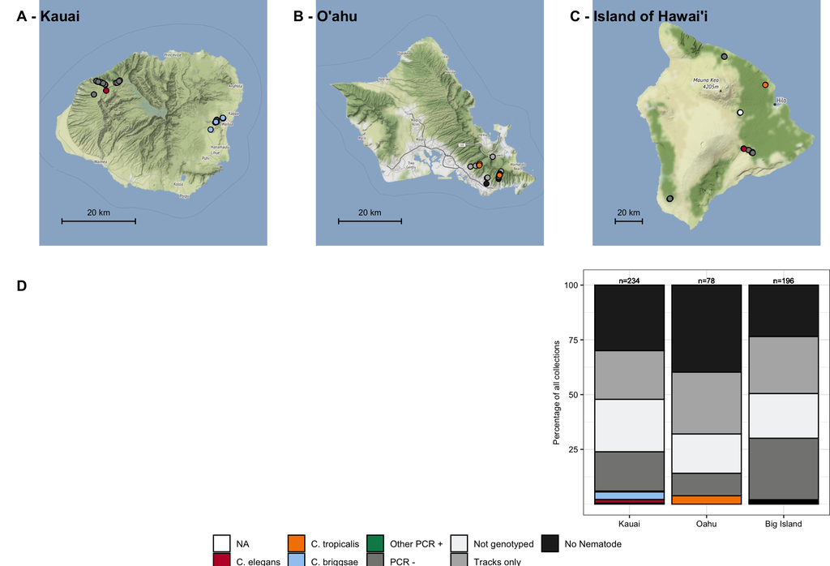

### Target species map

[interactive chart not shown]

### Remaining concerns as of 20200107

**1.** Two *C. elegans* isolations do not have paired collection data.  
**2.** Two living *Caenorhabditis* isolations (S-0632 and S-0669) have not yet been genotyped with the ITS2 primers.  
**3.** Two isolations (S-0879 and S-0868) have no species id although they produced ITS2 bands. Need to check them manually again.